title: "Project Write-Up 2" author: "Tyler Truong" date: "2025-05-06" output: html_document

```python
import matplotlib.pyplot as plt
import numpy as np
import pandas as pd
import seaborn as sns
from sklearn import cluster, metrics, model_selection, linear_model
```

# Netflix Movie Data Analysis

**Dataset**: [Netflix Movies and TV Shows Dataset](https://www.kaggle.com/datasets/muhammadtahir194/netflix-movies-and-tv-shows-dataset?resource=download)

This dataset includes Netflix titles with fields like:

- Title, type
- Cast and director
- Country and release year
- Duration
- Genre (listed_in)
- Description

For this project, I only used movies. I extracted `duration_minutes` as a numeric value and used one-hot encoding to turn genres into usable features.

```python
df = pd.read_csv("~/Downloads/netflix_titles.csv")
```

```python
df_movies = df[df['type'] == 'Movie'].copy()

df_movies['duration_minutes'] = df_movies['duration'].str.extract(r'(\d+)').astype(float)

total_movies = len(df_movies)

before_2000 = df_movies[df_movies['release_year'] < 2000]
between_2000_2014 = df_movies[(df_movies['release_year'] >= 2000) & (df_movies['release_year'] <= 2014)]
after_2015 = df_movies[df_movies['release_year'] >= 2015]

percent_before_2000 = len(before_2000) / total_movies * 100
percent_2000_2014 = len(between_2000_2014) / total_movies * 100
percent_after_2015 = len(after_2015) / total_movies * 100

print(f"Percent of movies released before 2000: {percent_before_2000:.1f}%")
print(f"Percent of movies released between 2000-2014: {percent_2000_2014:.1f}%")
print(f"Percent of movies released after 2015: {percent_after_2015:.1f}%")
```

```
Percent of movies released before 2000: 7.8%
Percent of movies released between 2000-2014: 26.7%
Percent of movies released after 2015: 65.5%
```

## Question 1: What are the most common movie genres?

Country of origin:

- **32%** U.S.
- **11%** India
- **57%** Other countries

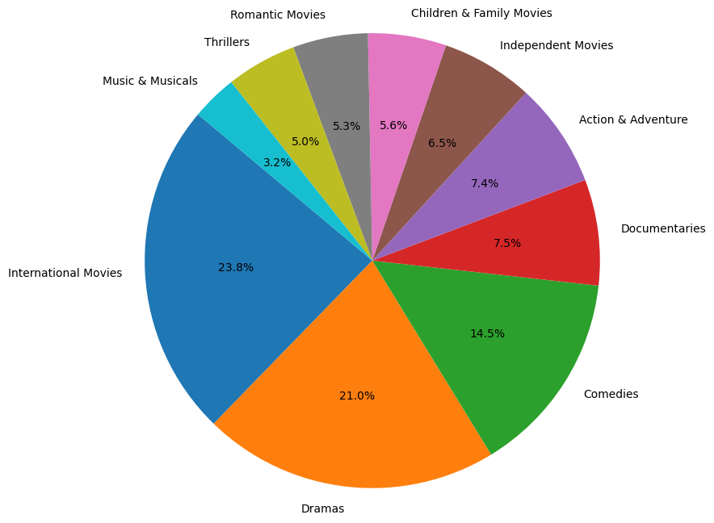

```python
genre_counts = df[df['type'] == 'Movie']['listed_in'].str.split(', ').explode().value_counts().head(10)

plt.figure(figsize=(8,8))
plt.pie(genre_counts.values, labels=genre_counts.index, autopct='%1.1f%%', startangle=140)
plt.axis('equal')
plt.show()
```

## Question 2: How many movies were released each year?

Netflix had very few old movies.

- About **7.8%** were from before 2000.
- About **26.7%** were released between 2000–2014.
- About **65.5%** came after 2015.

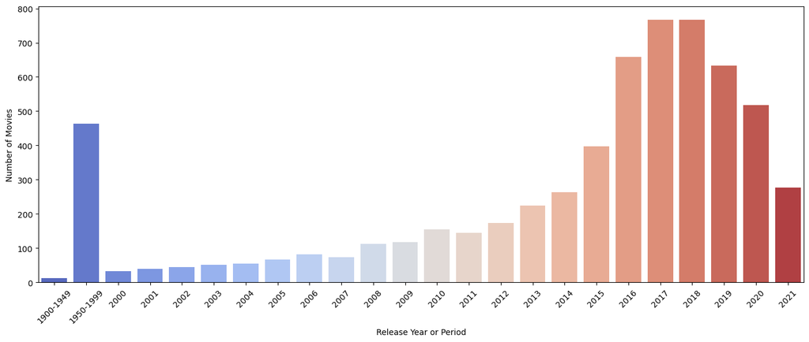

```python
def custom_group_year(year):
    if year < 1950:
        return '1900-1949'
    elif year < 2000:
        return '1950-1999'
    else:
        return str(year)  # 2000 and later as individual years

df_movies['year_group'] = df_movies['release_year'].apply(custom_group_year)

movies_per_group = df_movies['year_group'].value_counts().sort_index()

# Plot
plt.figure(figsize=(14,6))
sns.barplot(x=movies_per_group.index, y=movies_per_group.values, palette='coolwarm')
plt.xlabel('Release Year or Period')
plt.ylabel('Number of Movies')
plt.xticks(rotation=45)
plt.tight_layout()
plt.show()
```